# GP1: Omnichannel Journey Map

Author

Ron Sabilla, Kevin Bachez, Alexa Bueno, Sandy Zhu, Brian Vuong

Published

June 28, 2026

## 1 Step-by-Step Guidance

### 1.1 Step 1: Target Customer Segments

CPP Students, Faculty & Staff, Alumni, Local Community Members, and Online-First Shoppers are the main target segments for this omnichannel journey map of CPP Farm Store. These five groups, which include both on-campus and off-campus audiences with different but similar reasons for interacting with CPP Farm Store, were chosen because they are the most representative and frequent customers.

- **CPP Students:** One of the main customer bases who live and study on or near campus, making the store geographically accessible. They are motivated by affordability, convenience, and the novelty of buying university-produced food. They are active on social media and respond well to digital promotions, but many remain unaware that the store exists, making awareness building a critical opportunity.
- **Faculty and Staff:** Reliable, repeat customers who shop with intention (e.g., grabbing lunch or meeting items). They value consistency in hours and product availability, and are well-positioned to become habitual shoppers if the experience is seamless.
- **Alumni:** A high-value emotional segment with a built-in reason to support the store for gifting during holidays or milestone events. Often located off-campus, they depend heavily on digital channels (website, email, social media) to connect and require strong online ordering capabilities.
- **Local Community Members:** Off-campus shoppers (families, residents of Pomona/San Gabriel Valley) drawn to locally sourced products and the university farm story. They face the most friction regarding campus logistics (navigation, parking, store hours), representing a major opportunity for digital information optimization.
- **Online-First Shoppers:** Customers preferring a purely digital convenience workflow (researching, browsing, purchasing) over in-store browsing. They expect a fully functional e-commerce experience with clear product pages, accurate inventory, and reliable click-and-collect or delivery options. Capturing this segment requires prioritizing the Shopify storefront, product feed quality, and a seamless pickup process.

Together, these five segments share a common thread: They all need better awareness, clearer digital information, and a more connected experience between online discovery and in-store or pickup purchase. The journey map that follows is built around their overlapping goals and the friction points that currently stand between them and a satisfying CPP Farm Store experience.

## 2 Step 2: Customer Goals (Brian)

### 2.1 Target Segment: Local Community Members & Weekend Gift Buyers

- **Goal 1: Validate Product Availability Remotely**
  - *The Intent:* The customer wants to know if high-demand, hyper-seasonal items (like freshly squeezed CPP orange juice, dynamic holiday gift baskets, or specific harvest produce) are actually in stock before committing to driving onto a university campus.
- **Goal 2: Source an Authentic, Meaningful Gift**
  - *The Intent:* They want to buy a high-quality, locally produced item that tells a story (e.g., “made by Cal Poly Pomona agriculture students”) to present as a host gift or holiday token.
- **Goal 3: Bypass Campus Logistics Friction**
  - *The Intent:* They want to easily find accurate store hours, clear driving directions separate from general university navigation, and understand exactly where they can park legally without getting a campus parking citation.
- **Goal 4: Execute an Efficient “Click-and-Collect” Purchase**
  - *The Intent:* They want to browse, select, and pay online ahead of time so they can perform a quick, structured, friction-free physical pickup.

## 4 Step 4: Identify Touchpoints

[output not shown]

## 5 Data Visualization: Touchpoints per Stage

Below is an embedded R plot to help your group visualize the volume of touchpoints currently active across each stage of your omnichannel map.

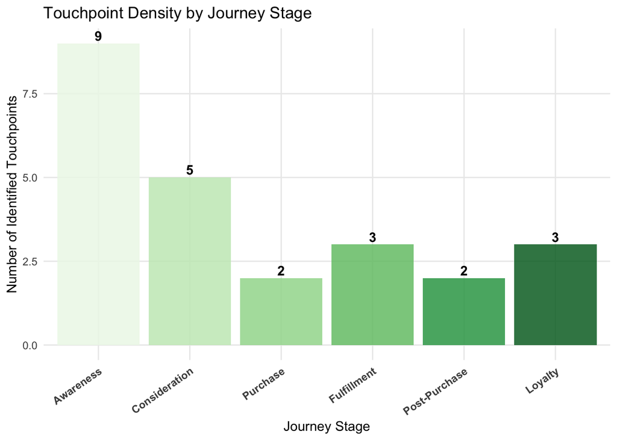

Distribution of Omnichannel Customer Touchpoints

```r
library(tidyverse)
library(tidymodels)
library(ggplot2)

# Create data frame from Step 4 touchpoint matrix counts
touchpoint_data <- data.frame(
  Stage = factor(c("Awareness", "Consideration", "Purchase", "Fulfillment", "Post-Purchase", "Loyalty"),
                 levels = c("Awareness", "Consideration", "Purchase", "Fulfillment", "Post-Purchase", "Loyalty")),
  Count = c(9, 5, 2, 3, 2, 3)
)

# Plot touchpoint distribution
ggplot(touchpoint_data, aes(x = Stage, y = Count, fill = Stage)) +
  geom_bar(stat = "identity", alpha = 0.85, show.legend = FALSE) +
  geom_text(aes(label = Count), vjust = -0.3, fontface = "bold") +
  scale_fill_brewer(palette = "Greens") +
  labs(
    title = "Touchpoint Density by Journey Stage",
    x = "Journey Stage",
    y = "Number of Identified Touchpoints"
  ) +
  theme_minimal() +
  theme(
    axis.text.x = element_text(angle = 35, hjust = 1, face = "bold"),
    panel.grid.minor = element_blank()
  )
```

## 6 Step 5: Pain Points (Alexa)

1. Many students, visitors, and community members are unaware that the CPP Farm Store exists or what products it offers.
2. Store hours, location information, and seasonal availability may be difficult to find across different channels.
3. Customers cannot easily browse products online before visiting the store, making it harder to plan purchases.
4. Product descriptions and images may be limited, preventing customers from learning more about locally produced items.
5. There is no clear or convenient online ordering and pickup process, which may discourage busy students and faculty from purchasing.
6. Promotions and seasonal campaigns are not always integrated across social media, email, and in-store signage, resulting in inconsistent messaging.
7. Customers who make a purchase may not receive follow-up communication, reducing opportunities for repeat purchases.
8. There is limited personalization or loyalty communication to encourage long-term customer relationships.

## 7 Step 6: Omnichannel Opportunities (Alexa)

1. Increase awareness by improving Google Search visibility, optimizing Google Business Profile, and promoting the store through social media and campus channels.
2. Create a user-friendly Shopify website that clearly displays store hours, location information, featured products, and seasonal offerings.
3. Develop detailed product pages with high-quality images, pricing, descriptions, and information about local sourcing.
4. Introduce online ordering with options such as in-store pickup to provide greater convenience for students, faculty, and visitors.
5. Launch integrated seasonal campaigns across Instagram, email, campus events, and in-store signage to provide a consistent omnichannel experience.
6. Implement Google Merchant Center and retail media channels to improve product discoverability and drive online traffic.
7. Use post-purchase emails to thank customers, request reviews, recommend related products, and promote upcoming events.
8. Establish a loyalty or rewards program that encourages repeat purchases and strengthens customer engagement.
9. Use analytics dashboards to monitor customer behavior, track campaign performance, and identify opportunities for continuous improvement.

## 8 Visual Journey Map

Link to **Canva** for the Visual Journey Map https://canva.link/952hyp52b1k6upp